# Assignment #2 ‐ Differential Gene expression and Preliminary ORA

Gen Li

2024-03-12

# Introduction

This notebook records the Differential Gene Expression analysis and Thresholded over-representation analysis of the normalized data generated from Assignment 1. In general, the data with ID GSE199089(Cheng et al. 2022), was found in the [GEO](https://www.ncbi.nlm.nih.gov/geo/) database, published by a [paper](https://pubmed.ncbi.nlm.nih.gov/35534729/)(Cheng et al. 2022) (please click the link to access). The data is mainly for comparing the differential expression of genes under different treatment of glutamine or glucose or NH4+. In the Assignment 1, the following steps were performed to process the data:

- Compute quality control statistics to assess data quality
- Map the original Gene symbols (Ensembl ID) to HUGO gene symbols and deal with abnormal situations
- Clean the data by removing outliers or data with significant errors
- Apply normalization on the data and generate the data frame as required

The data has HUGO gene symbols as its row names, sample IDs/names as its column names, each cell of the matrix contains the normalized expression value of each gene in each sample.

In this notebook, the differential Gene expression analysis will be performed first using edgeR package, then for genes that have significant up-regulated/down-regulated genes, the Thresholded over-representation analysis will performed by using gprofiler2 package. First, we need to install all required packages.

Install all necessary packages(Morgan and Ramos 2023) (Xie 2023) (Robinson, McCarthy, and Smyth 2010) (Wickham 2016) (Wickham et al. 2023) (Slowikowski 2024) (Kolberg et al. 2020) (Gu 2022) (Gu et al. 2014):

```r
# Check if all required packages are installed and install them if not
if (!require("BiocManager", quietly = TRUE))
    install.packages("BiocManager")

if (!require("edgeR", quietly = TRUE))
    BiocManager::install("edgeR")

if (!require("knitr", quietly = TRUE))
    install.packages("knitr")

if (!require("ggplot2", quietly = TRUE))
    install.packages("ggplot2")

if (!require("dplyr", quietly = TRUE))
    install.packages("dplyr")

if (!require("ggrepel", quietly = TRUE))
    install.packages("ggrepel")

if (!require("gprofiler2", quietly = TRUE))
    install.packages("gprofiler2")

if (!require("ComplexHeatmap", quietly = TRUE))
    BiocManager::install("ComplexHeatmap")

if (!require("circlize", quietly = TRUE))
    install.packages("circlize")

if (!require("tidyverse", quietly = TRUE))
    install.packages("tidyverse")

library(edgeR)
library(knitr)
library(ggplot2)
library(dplyr)
library(ggrepel)
library(gprofiler2)
library(ComplexHeatmap)
library(circlize)
```

# Differential Gene Expression Analysis

## Load normalized Data

Directly load the data from my github Repository.

```r
normalized_expression_matrix_HUGO <- readRDS("normalized_expression_matrix_HUGO.rds")
normalized_expression_matrix_HUGO <- cbind(normalized_expression_matrix_HUGO, symbol = rownames(normalized_expression_matrix_HUGO))
```

Here we have a quick look at the normalized data:

```r
normalized_expression_matrix_HUGO[1:5, ]
```

```
##             Gln1      Gln2       Gln3      Glu1      Glu2      Glu3  Glu_Gln_1
## TSPAN6  20.11897  24.43468  22.224891  23.55118  22.75758  21.80698  26.924333
## DPM1    47.06733  46.15439  45.432098  55.45742  53.77444  55.05664  52.885058
## SCYL3   13.16655  13.27316  13.015682  11.77559  13.90411  12.04177   8.615787
## FIRRM   10.89009  11.61401   9.147814  13.68211  13.78527  13.06023  18.025132
## FUCA2  108.90087 109.55384 109.098429 105.36350 106.65758 112.92901 117.503458
##         Glu_Gln_2 Glu_Gln_3 Glu_NH4_1 Glu_NH4_2 Glu_NH4_3     ctrl1      ctrl2
## TSPAN6  28.930316  29.53652  23.64605  24.41495  24.10716  34.59775  32.480146
## DPM1    51.978534  52.59337  52.34574  54.59859  52.50565  70.24990  63.954954
## SCYL3    9.603424  10.09750  12.16617  13.28546  11.80115  10.87358   8.506705
## FIRRM   21.547683  19.81701  12.10378  13.05238  13.50506  27.21690  25.520115
## FUCA2  113.140342 117.12014 120.16435 118.05415 117.38043 178.85388 171.835440
##             ctrl3 symbol
## TSPAN6  37.207065 TSPAN6
## DPM1    73.400101   DPM1
## SCYL3    8.190234  SCYL3
## FIRRM   26.520759  FIRRM
## FUCA2  164.662713  FUCA2
```

```r
print(dim(normalized_expression_matrix_HUGO))
```

```
## [1] 13930    16
```

## MDS Plot

We can use MDS plot to check if the samples with the same conditions cluster with each other closely. The result turns out to be pretty impressive. Samples with the same conditions cluster with each other very closely (this is exactly what we want). The legend means that if the sample is treated by nothing/glutamine/glucose/glutamine+glucose/glucose+NH4+.

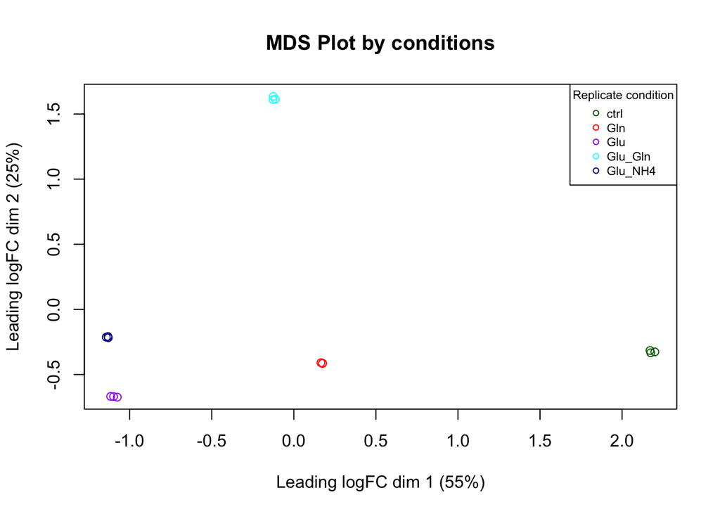

```r
group <- c("Gln", "Gln", "Gln", "Glu", "Glu", "Glu", "Glu_Gln", "Glu_Gln",
           "Glu_Gln", "Glu_NH4", "Glu_NH4", "Glu_NH4", "ctrl", "ctrl", "ctrl")

y <- DGEList(counts=normalized_expression_matrix_HUGO[,1:15],group=group)

plotMDS(y, labels=NULL, pch = 1, top = 100,
        col = c("darkgreen", "red", "purple", "cyan", "darkblue")[
          factor(group)])

title(main = "MDS Plot by conditions")
legend("topright",
       legend = levels(factor(group)),
       col = c("darkgreen", "red", "purple", "cyan", "darkblue"),
       pch = 1,
       cex = 0.7,
       title = "Replicate condition")
```

## Design the model & Perform the DE analysis

According to the [UserGuide](https://bioconductor.org/packages/release/bioc/vignettes/edgeR/inst/doc/edgeRUsersGuide.pdf) page 31 from [edgeR](https://bioconductor.org/packages/release/bioc/html/edgeR.html)(Robinson, McCarthy, and Smyth 2010). I am going to design the model for the differential gene expression. Since I have multiple replicates, I am going to use the GLM approach instead of the classic approach. In the codes below, the 0+ in the model formula is an instruction not to include an intercept column and instead to include a column for each group.

```r
design <- model.matrix(~0+group)
y <- estimateDisp(y,design)
colnames(design) <- levels(y$samples$group)
```

After defining the design matrix. The differential expression analysis will be performed. Here I decided to use the Quasi likelihood model, since it is used for more complicated models and is highly recommended for bulk RNASeq experiments (perfectly match the data I have).

Apart from that, I can compare any of the treatment groups using the contrast argument of the glmQLFTest function (see codes below). Here I tried to compare the control groups with each of the treatment condition group.

**Gln vs ctrl**

```r
fit <- glmQLFit(y, design)

my.contrasts <- makeContrasts(Glnvsctrl=Gln-ctrl, Gluvsctrl=Glu-ctrl, Glu_Glnvsctrl=Glu_Gln-ctrl, Glu_NH4vsctrl=Glu_NH4-ctrl, levels=design)

qlf.Glnvsctrl <- glmQLFTest(fit, contrast=my.contrasts[,"Glnvsctrl"])
Glnvsctrl_result <- topTags(qlf.Glnvsctrl, adjust.method = "BH", n = length(rownames(qlf.Glnvsctrl$table)))
print(Glnvsctrl_result[1:10, ])
```

```
## Coefficient:  -1*ctrl 1*Gln
##              logFC    logCPM        F       PValue          FDR
## HSP90AA1 -2.107312 12.868274 88533.71 2.221565e-86 3.094640e-82
## DNAJB1   -3.690199 10.890898 75048.99 1.693290e-84 1.179376e-80
## HSPA1B   -2.690120 12.283458 57369.91 1.939963e-81 9.007897e-78
## HSPA5     2.922896 11.237365 48614.55 1.490257e-79 5.189819e-76
## HSP90B1   2.663775 10.581340 42109.52 6.435213e-78 1.792850e-74
## HSPA6    -4.059980  9.072964 37752.96 1.126212e-76 2.614689e-73
## UBC      -2.280471 11.655737 34384.27 1.304108e-75 2.595175e-72
## JUN      -3.879536  8.694824 32914.26 4.097551e-75 7.134860e-72
## FOS      -3.745048  8.021346 31446.81 1.353599e-74 2.095070e-71
## HSPA1A   -2.631684 12.377961 30494.02 3.030829e-74 4.221945e-71
```

```r
length(which(Glnvsctrl_result$table$FDR < 0.05))
```

```
## [1] 5786
```

```r
length(which(Glnvsctrl_result$table$PValue < 0.05))
```

```
## [1] 6637
```

**Glu vs ctrl**

```r
qlf.Gluvsctrl <- glmQLFTest(fit, contrast=my.contrasts[,"Gluvsctrl"])
Gluvsctrl_result <- topTags(qlf.Gluvsctrl, adjust.method = "BH", n = length(rownames(qlf.Gluvsctrl$table)))
print(Gluvsctrl_result[1:10, ])
```

```
## Coefficient:  -1*ctrl 1*Glu
##               logFC    logCPM         F       PValue          FDR
## HSP90AA1  -3.149480 12.868274 118087.98 1.162665e-89 1.619592e-85
## DNAJB1    -5.391119 10.890898  93491.28 5.321662e-87 3.706537e-83
## HSPA1B    -8.108753 12.283458  90632.19 1.201780e-86 5.580266e-83
## HSPA6    -10.105347  9.072964  49633.48 8.651734e-80 3.012966e-76
## HSPA1A    -8.124772 12.377961  47923.18 2.169358e-79 6.043830e-76
## FOS       -5.841757  8.021346  39261.37 4.033807e-77 9.365156e-74
## UBC       -2.605347 11.655737  38960.44 4.935046e-77 9.820741e-74
## HSPA8     -2.918022 11.894496  38414.22 7.144851e-77 1.244097e-73
## BAG3      -4.665847  8.637662  37568.28 1.280654e-76 1.982168e-73
## DNAJA1    -3.692422  9.036535  33479.82 2.622132e-75 3.652630e-72
```

```r
length(which(Gluvsctrl_result$table$FDR < 0.05))
```

```
## [1] 6935
```

```r
length(which(Gluvsctrl_result$table$PValue < 0.05))
```

```
## [1] 7533
```

**Glu_Gln vs ctrl**

```r
qlf.Glu_Glnvsctrl <- glmQLFTest(fit, contrast=my.contrasts[,"Glu_Glnvsctrl"])

Glu_Glnvsctrl_result <- topTags(qlf.Glu_Glnvsctrl, adjust.method = "BH", n = length(rownames(qlf.Glu_Glnvsctrl$table)))
print(Glu_Glnvsctrl_result[1:10, ])
```

```
## Coefficient:  -1*ctrl 1*Glu_Gln
##              logFC    logCPM        F       PValue          FDR
## HSPA1B   -5.648510 12.283458 83785.44 9.430452e-86 7.860626e-82
## DNAJB1   -4.458404 10.890898 83213.60 1.128590e-85 7.860626e-82
## HSP90AA1 -1.531119 12.868274 62223.85 2.306464e-82 1.070968e-78
## HSPA6    -9.990561  9.072964 49161.52 1.111431e-79 3.870558e-76
## UBC      -3.174494 11.655737 47516.47 2.712449e-79 7.556882e-76
## HSPA1A   -5.594138 12.377961 44350.97 1.652764e-78 3.837167e-75
## FOS      -7.639018  8.021346 41891.64 7.372490e-78 1.467126e-74
## PPP1R15A -5.510890  9.082865 36788.31 2.219273e-76 3.864309e-73
## JUN      -4.668417  8.694824 35623.43 5.157096e-76 7.982038e-73
## BAG3     -3.547484  8.637662 30542.56 2.907126e-74 4.049626e-71
```

```r
length(which(Glu_Glnvsctrl_result$table$FDR < 0.05))
```

```
## [1] 5853
```

```r
length(which(Glu_Glnvsctrl_result$table$PValue < 0.05))
```

```
## [1] 6743
```

**Glu_NH4 vs ctrl**

```r
qlf.Glu_NH4vsctrl <- glmQLFTest(fit, contrast=my.contrasts[,"Glu_NH4vsctrl"])

Glu_NH4vsctrl_result <- topTags(qlf.Glu_NH4vsctrl, adjust.method = "BH", n = length(rownames(qlf.Glu_NH4vsctrl$table)))
print(Glu_NH4vsctrl_result[1:10, ])
```

```
## Coefficient:  -1*ctrl 1*Glu_NH4
##               logFC    logCPM         F       PValue          FDR
## HSP90AA1  -3.198502 12.868274 118840.15 9.842883e-90 1.371114e-85
## DNAJB1    -5.322787 10.890898  92370.43 7.301866e-87 5.085750e-83
## HSPA1B    -8.119203 12.283458  90284.49 1.329254e-86 6.172171e-83
## HSPA6    -10.663443  9.072964  49436.27 9.603520e-80 3.344426e-76
## HSPA1A    -8.192831 12.377961  47782.95 2.342576e-79 6.526418e-76
## FOS       -6.419782  8.021346  40270.35 2.074427e-77 4.816127e-74
## BAG3      -4.633508  8.637662  37167.83 1.695898e-76 3.374837e-73
## UBC       -2.477946 11.655737  36632.65 2.480092e-76 3.921449e-73
## HSPA8     -2.799938 11.894496  36602.82 2.533600e-76 3.921449e-73
## JUN       -4.310536  8.694824  33943.61 1.828510e-75 2.547114e-72
```

```r
length(which(Glu_NH4vsctrl_result$table$FDR < 0.05))
```

```
## [1] 6792
```

```r
length(which(Glu_NH4vsctrl_result$table$PValue < 0.05))
```

```
## [1] 7495
```

For all the differential expression analysis happened above, I decided to use the BH (Benjamni Hochberg) method for the correction of multiple hypothesis testing.

## Visualization with Heatmap

After performing the differential gene expression analysis, visualizations of top hits genes using heatmaps and volcano plots are generated.

```r
normalized_expression_matrix_HUGO <- readRDS("normalized_expression_matrix_HUGO.rds")

heatmap_matrix <- normalized_expression_matrix_HUGO[, 1:ncol(normalized_expression_matrix_HUGO)]
```

**For Gln vs ctrl group**

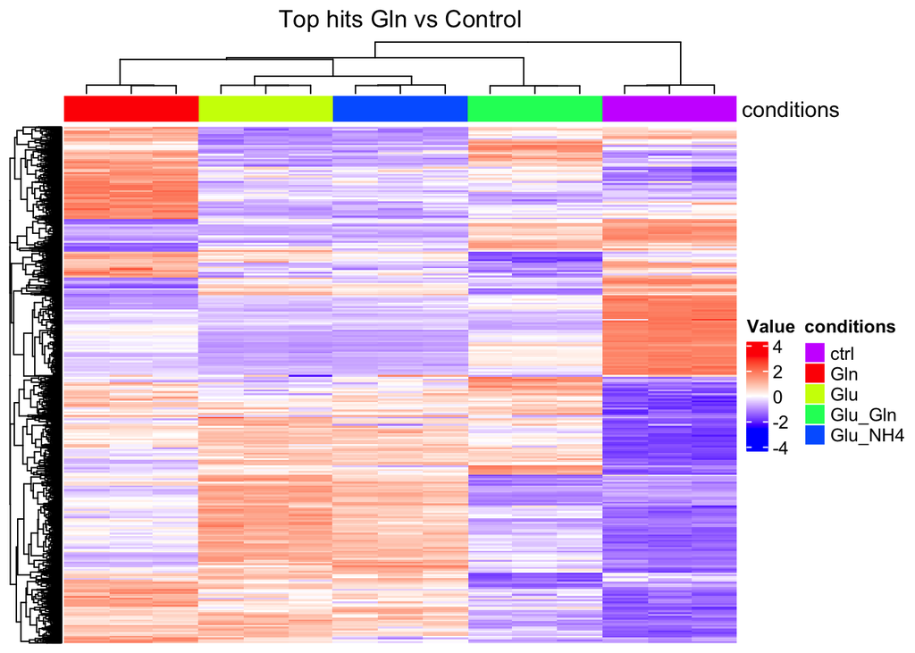

```r
top_hits <- rownames(Glnvsctrl_result$table)[Glnvsctrl_result$table$FDR<0.05]
heatmap_matrix_tophits <- t(
  scale(t(heatmap_matrix[which(rownames(heatmap_matrix) %in% top_hits),])))

if(min(heatmap_matrix_tophits) == 0){
  heatmap_col = colorRamp2(c( 0, max(heatmap_matrix_tophits)),
                           c( "white", "red"))
} else {
  heatmap_col = colorRamp2(c(min(heatmap_matrix_tophits), 0,
                             max(heatmap_matrix_tophits)), c("blue", "white", "red"))
}


# Add annotations to heatmap
group_condition <- unique(group)
unique_conditioncolors <- rainbow(n = length(group_condition))
names(unique_conditioncolors) <- group_condition

annotation <- HeatmapAnnotation(df = data.frame(
  conditions = group),
  col = list(conditions = unique_conditioncolors),
  show_legend = TRUE)

Heatmap(as.matrix(heatmap_matrix_tophits),
       top_annotation = annotation,
       name = "Value",
       cluster_rows = TRUE,
       cluster_columns = TRUE,
       show_row_dend = TRUE,
       show_column_dend = TRUE,
       col=heatmap_col,
       show_column_names = FALSE,
       show_row_names = FALSE,
       show_heatmap_legend = TRUE,
       column_title =("Top hits Gln vs Control")
)
```

**For Glu vs ctrl group**

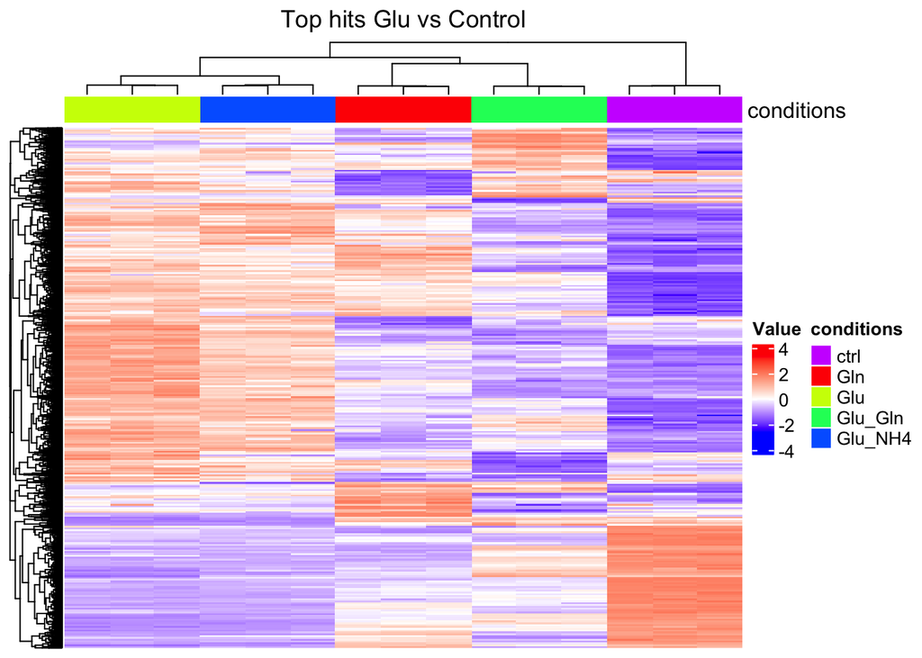

```r
top_hits <- rownames(Gluvsctrl_result$table)[Gluvsctrl_result$table$FDR<0.05]
heatmap_matrix_tophits <- t(
  scale(t(heatmap_matrix[which(rownames(heatmap_matrix) %in% top_hits),])))

if(min(heatmap_matrix_tophits) == 0){
  heatmap_col = colorRamp2(c( 0, max(heatmap_matrix_tophits)),
                           c( "white", "red"))
} else {
  heatmap_col = colorRamp2(c(min(heatmap_matrix_tophits), 0,
                             max(heatmap_matrix_tophits)), c("blue", "white", "red"))
}


# Add annotations to heatmap
group_condition <- unique(group)
unique_conditioncolors <- rainbow(n = length(group_condition))
names(unique_conditioncolors) <- group_condition

annotation <- HeatmapAnnotation(df = data.frame(
  conditions = group),
  col = list(conditions = unique_conditioncolors),
  show_legend = TRUE)

Heatmap(as.matrix(heatmap_matrix_tophits),
       top_annotation = annotation,
       name = "Value",
       cluster_rows = TRUE,
       cluster_columns = TRUE,
       show_row_dend = TRUE,
       show_column_dend = TRUE,
       col=heatmap_col,
       show_column_names = FALSE,
       show_row_names = FALSE,
       show_heatmap_legend = TRUE,
       column_title =("Top hits Glu vs Control")
)
```

**For Glu_Gln vs ctrl group**

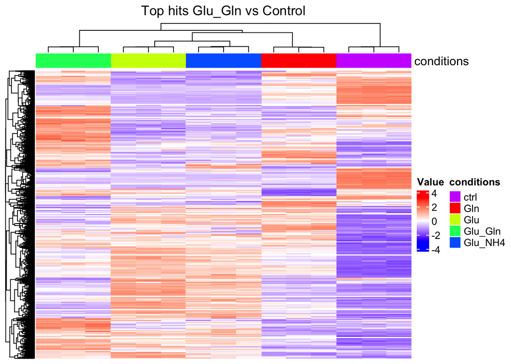

```r
top_hits <- rownames(Glu_Glnvsctrl_result$table)[Glu_Glnvsctrl_result$table$FDR<0.05]
heatmap_matrix_tophits <- t(
  scale(t(heatmap_matrix[which(rownames(heatmap_matrix) %in% top_hits),])))

if(min(heatmap_matrix_tophits) == 0){
  heatmap_col = colorRamp2(c( 0, max(heatmap_matrix_tophits)),
                           c( "white", "red"))
} else {
  heatmap_col = colorRamp2(c(min(heatmap_matrix_tophits), 0,
                             max(heatmap_matrix_tophits)), c("blue", "white", "red"))
}


# Add annotations to heatmap
group_condition <- unique(group)
unique_conditioncolors <- rainbow(n = length(group_condition))
names(unique_conditioncolors) <- group_condition

annotation <- HeatmapAnnotation(df = data.frame(
  conditions = group),
  col = list(conditions = unique_conditioncolors),
  show_legend = TRUE)

Heatmap(as.matrix(heatmap_matrix_tophits),
       top_annotation = annotation,
       name = "Value",
       cluster_rows = TRUE,
       cluster_columns = TRUE,
       show_row_dend = TRUE,
       show_column_dend = TRUE,
       col=heatmap_col,
       show_column_names = FALSE,
       show_row_names = FALSE,
       show_heatmap_legend = TRUE,
       column_title =("Top hits Glu_Gln vs Control")
)
```

**For Glu_NH4 vs ctrl group**

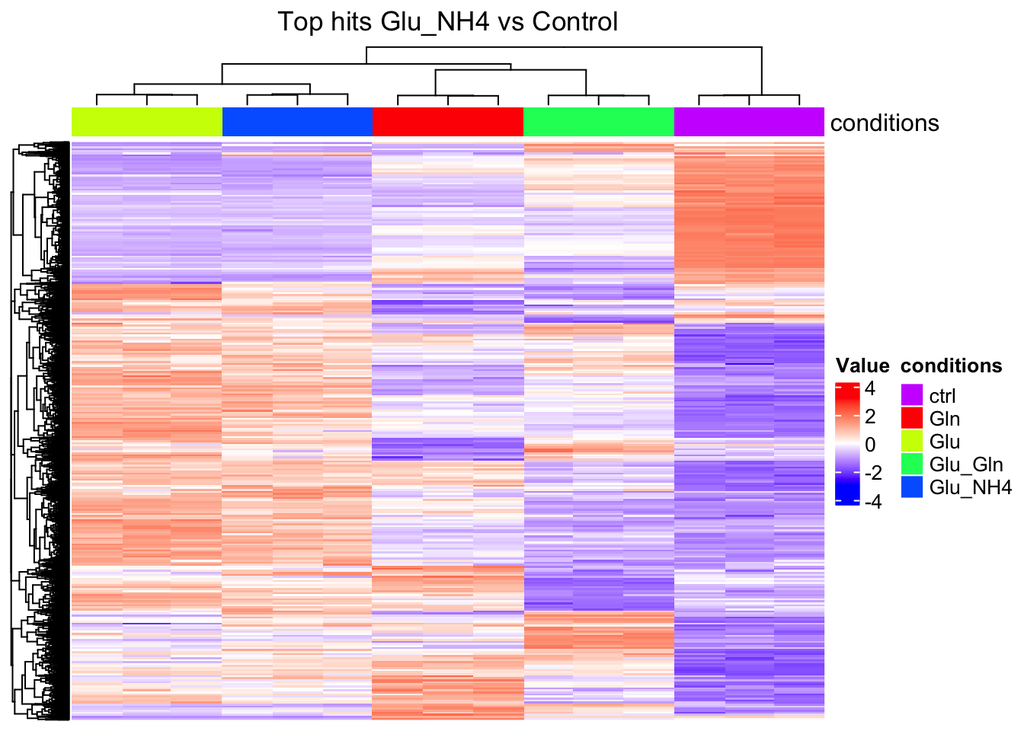

```r
top_hits <- rownames(Glu_NH4vsctrl_result$table)[Glu_NH4vsctrl_result$table$FDR<0.05]
heatmap_matrix_tophits <- t(
  scale(t(heatmap_matrix[which(rownames(heatmap_matrix) %in% top_hits),])))

if(min(heatmap_matrix_tophits) == 0){
  heatmap_col = colorRamp2(c( 0, max(heatmap_matrix_tophits)),
                           c( "white", "red"))
} else {
  heatmap_col = colorRamp2(c(min(heatmap_matrix_tophits), 0,
                             max(heatmap_matrix_tophits)), c("blue", "white", "red"))
}


# Add annotations to heatmap
group_condition <- unique(group)
unique_conditioncolors <- rainbow(n = length(group_condition))
names(unique_conditioncolors) <- group_condition

annotation <- HeatmapAnnotation(df = data.frame(
  conditions = group),
  col = list(conditions = unique_conditioncolors),
  show_legend = TRUE)

Heatmap(as.matrix(heatmap_matrix_tophits),
       top_annotation = annotation,
       name = "Value",
       cluster_rows = TRUE,
       cluster_columns = TRUE,
       show_row_dend = TRUE,
       show_column_dend = TRUE,
       col=heatmap_col,
       show_column_names = FALSE,
       show_row_names = FALSE,
       show_heatmap_legend = TRUE,
       column_title =("Top hits Glu_NH4 vs Control")
)
```

It is easy to see that the groups treated with the same conditions significantly tend to cluster together. This is a very good result, and such behavior is expected. In the [paper](https://pubmed.ncbi.nlm.nih.gov/35534729/)(Cheng et al. 2022), they treat the samples with different conditions to explore their effect on the expression of genes regulating fatty acid and cholesterol synthesis, the clustering of the groups with same conditions confirm that the experiment design is relatively reliable and reproducible.

## Visualization with Volcano Plots

I also plot the differential expression result by Volcano plot to identify some genes of interest:

**For Gln vs ctrl group**

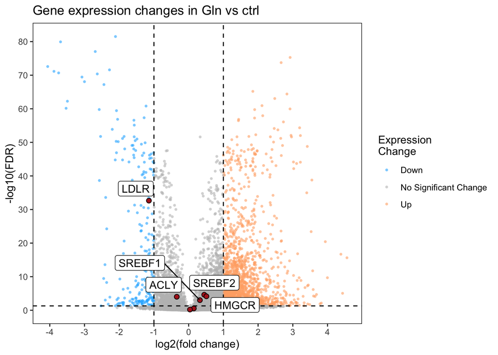

```r
result <- Glnvsctrl_result$table %>%
  mutate(gene_type = case_when(logFC >= 1 & FDR <= 0.05 ~ "Up",
                               logFC <= -1 & FDR <= 0.05 ~ "Down",
                               TRUE ~ "No Significant Change"))
result <- cbind(result, symbol=rownames(result))


cols <- c("Up" = "#ffad73", "Down" = "#26b3ff", "No Significant Change" = "grey")

genes_interest <- result %>%
  filter(symbol %in% c("SREBF1", "SREBF2", "ACLY", "ACACA", "FASN", "SCD1", "HMGCR", "LDLR"))


ggplot(data = result,
       aes(x = logFC,
           y = -log10(FDR))) +
  geom_point(aes(colour = gene_type),
             alpha = 0.6,
             shape = 16,
             size = 1) +
  geom_point(data = genes_interest,
             shape = 21,
             size = 2,
             fill = "firebrick",
             colour = "black") +
  geom_hline(yintercept = -log10(0.05),
             linetype = "dashed") +
  geom_vline(xintercept = c(log2(0.5), log2(2)),
             linetype = "dashed") +
  geom_label_repel(data = genes_interest, # Add labels last to appear as the top layer
                   aes(label = symbol),
                   force = 2,
                   nudge_y = 1) +
  scale_colour_manual(values = cols) +
  scale_x_continuous(breaks = c(seq(-5, 5, 1))) +
  scale_y_continuous(breaks = c(seq(0, 85, 10))) +
  labs(title = "Gene expression changes in Gln vs ctrl",
       x = "log2(fold change)",
       y = "-log10(FDR)",
       colour = "Expression \nChange") +
  theme_bw() + # Select theme with a white background
  theme(panel.border = element_rect(colour = "black", fill = NA, size= 0.5),
        panel.grid.minor = element_blank(),
        panel.grid.major = element_blank())
```

**For Glu vs ctrl group**

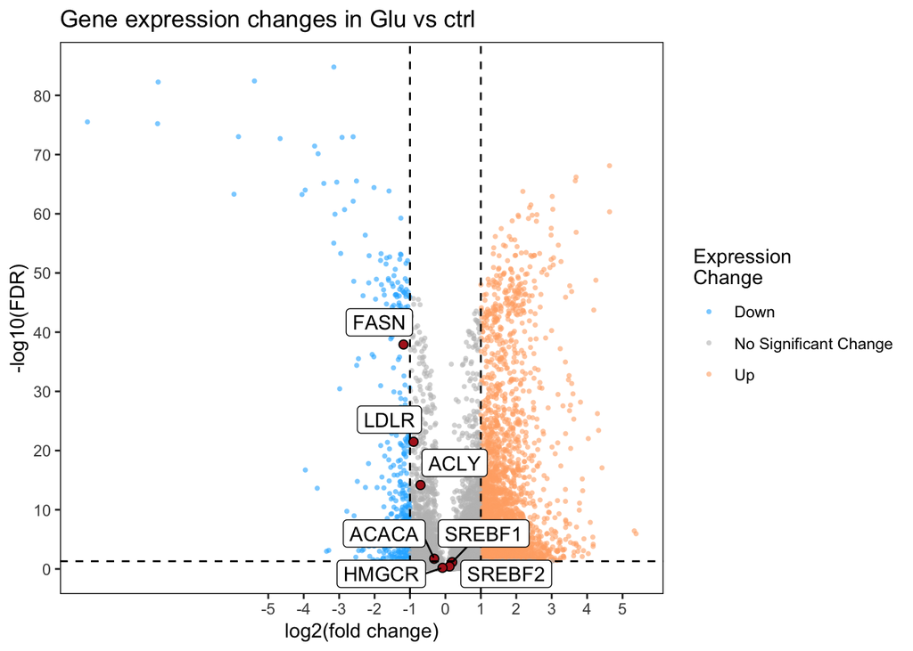

```r
result <- Gluvsctrl_result$table %>%
  mutate(gene_type = case_when(logFC >= 1 & FDR <= 0.05 ~ "Up",
                               logFC <= -1 & FDR <= 0.05 ~ "Down",
                               TRUE ~ "No Significant Change"))
result <- cbind(result, symbol=rownames(result))


cols <- c("Up" = "#ffad73", "Down" = "#26b3ff", "No Significant Change" = "grey")

genes_interest <- result %>%
  filter(symbol %in% c("SREBF1", "SREBF2", "ACLY", "ACACA", "FASN", "SCD1", "HMGCR", "LDLR"))


ggplot(data = result,
       aes(x = logFC,
           y = -log10(FDR))) +
  geom_point(aes(colour = gene_type),
             alpha = 0.6,
             shape = 16,
             size = 1) +
  geom_point(data = genes_interest,
             shape = 21,
             size = 2,
             fill = "firebrick",
             colour = "black") +
  geom_hline(yintercept = -log10(0.05),
             linetype = "dashed") +
  geom_vline(xintercept = c(log2(0.5), log2(2)),
             linetype = "dashed") +
  geom_label_repel(data = genes_interest, # Add labels last to appear as the top layer
                   aes(label = symbol),
                   force = 2,
                   nudge_y = 1) +
  scale_colour_manual(values = cols) +
  scale_x_continuous(breaks = c(seq(-5, 5, 1))) +
  scale_y_continuous(breaks = c(seq(0, 85, 10))) +
  labs(title = "Gene expression changes in Glu vs ctrl",
       x = "log2(fold change)",
       y = "-log10(FDR)",
       colour = "Expression \nChange") +
  theme_bw() + # Select theme with a white background
  theme(panel.border = element_rect(colour = "black", fill = NA, size= 0.5),
        panel.grid.minor = element_blank(),
        panel.grid.major = element_blank())
```

**For Glu_Gln vs ctrl group**

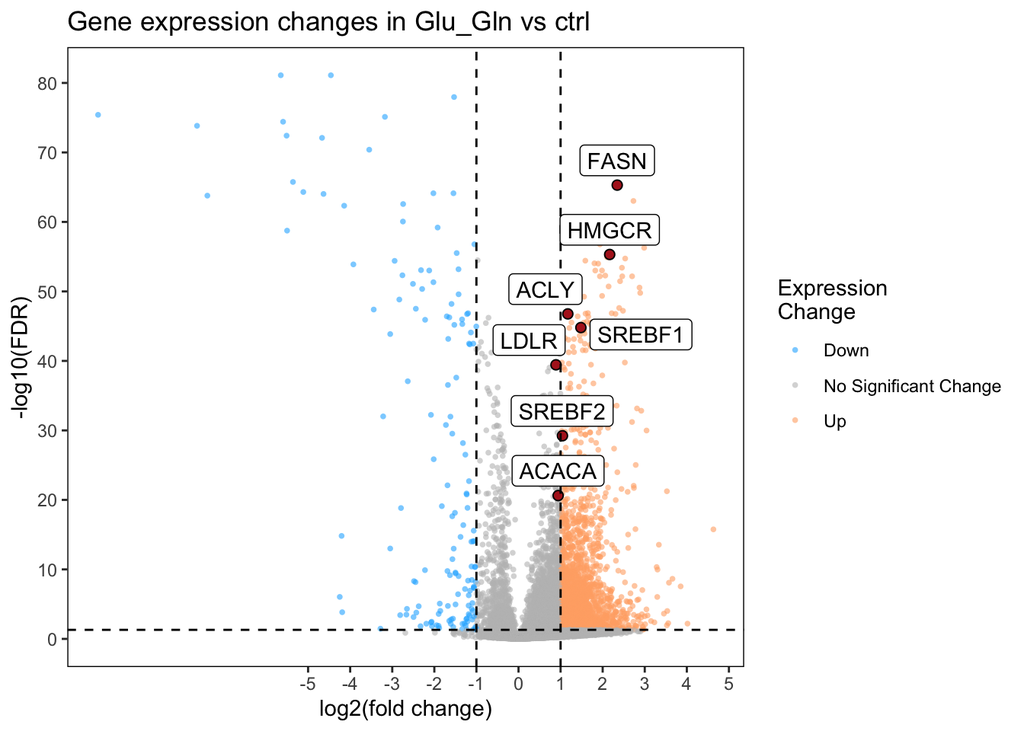

```r
result <- Glu_Glnvsctrl_result$table %>%
  mutate(gene_type = case_when(logFC >= 1 & FDR <= 0.05 ~ "Up",
                               logFC <= -1 & FDR <= 0.05 ~ "Down",
                               TRUE ~ "No Significant Change"))
result <- cbind(result, symbol=rownames(result))


cols <- c("Up" = "#ffad73", "Down" = "#26b3ff", "No Significant Change" = "grey")

genes_interest <- result %>%
  filter(symbol %in% c("SREBF1", "SREBF2", "ACLY", "ACACA", "FASN", "SCD1", "HMGCR", "LDLR"))


ggplot(data = result,
       aes(x = logFC,
           y = -log10(FDR))) +
  geom_point(aes(colour = gene_type),
             alpha = 0.6,
             shape = 16,
             size = 1) +
  geom_point(data = genes_interest,
             shape = 21,
             size = 2,
             fill = "firebrick",
             colour = "black") +
  geom_hline(yintercept = -log10(0.05),
             linetype = "dashed") +
  geom_vline(xintercept = c(log2(0.5), log2(2)),
             linetype = "dashed") +
  geom_label_repel(data = genes_interest, # Add labels last to appear as the top layer
                   aes(label = symbol),
                   force = 2,
                   nudge_y = 1) +
  scale_colour_manual(values = cols) +
  scale_x_continuous(breaks = c(seq(-5, 5, 1))) +
  scale_y_continuous(breaks = c(seq(0, 85, 10))) +
  labs(title = "Gene expression changes in Glu_Gln vs ctrl",
       x = "log2(fold change)",
       y = "-log10(FDR)",
       colour = "Expression \nChange") +
  theme_bw() + # Select theme with a white background
  theme(panel.border = element_rect(colour = "black", fill = NA, size= 0.5),
        panel.grid.minor = element_blank(),
        panel.grid.major = element_blank())
```

**For Glu_NH4 vs ctrl group**

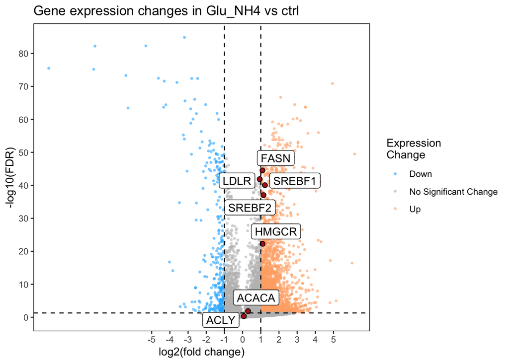

```r
result <- Glu_NH4vsctrl_result$table %>%
  mutate(gene_type = case_when(logFC >= 1 & FDR <= 0.05 ~ "Up",
                               logFC <= -1 & FDR <= 0.05 ~ "Down",
                               TRUE ~ "No Significant Change"))
result <- cbind(result, symbol=rownames(result))


cols <- c("Up" = "#ffad73", "Down" = "#26b3ff", "No Significant Change" = "grey")

genes_interest <- result %>%
  filter(symbol %in% c("SREBF1", "SREBF2", "ACLY", "ACACA", "FASN", "SCD1", "HMGCR", "LDLR"))


ggplot(data = result,
       aes(x = logFC,
           y = -log10(FDR))) +
  geom_point(aes(colour = gene_type),
             alpha = 0.6,
             shape = 16,
             size = 1) +
  geom_point(data = genes_interest,
             shape = 21,
             size = 2,
             fill = "firebrick",
             colour = "black") +
  geom_hline(yintercept = -log10(0.05),
             linetype = "dashed") +
  geom_vline(xintercept = c(log2(0.5), log2(2)),
             linetype = "dashed") +
  geom_label_repel(data = genes_interest, # Add labels last to appear as the top layer
                   aes(label = symbol),
                   force = 2,
                   nudge_y = 1) +
  scale_colour_manual(values = cols) +
  scale_x_continuous(breaks = c(seq(-5, 5, 1))) +
  scale_y_continuous(breaks = c(seq(0, 85, 10))) +
  labs(title = "Gene expression changes in Glu_NH4 vs ctrl",
       x = "log2(fold change)",
       y = "-log10(FDR)",
       colour = "Expression \nChange") +
  theme_bw() + # Select theme with a white background
  theme(panel.border = element_rect(colour = "black", fill = NA, size= 0.5),
        panel.grid.minor = element_blank(),
        panel.grid.major = element_blank())
```

According tot he Volcano Plots above, when treating the sample with only glutamine or glucose, the expression of genes of interest (genes that regulating fatty acid and cholesterol synthesis) has no significant up-regulation. Then treating the sample with both glutamine and glucose or both glucose and NH4+ would generally up-regulate the expression of the genes that regulate fatty acid and cholesterol synthesis. And it can also be seen that glutamine and glucose has relatively better effect on up-regulation of genes of interest than glucose and NH4+.

## Questions to answer for the Differential expression section

**How many genes were significantly differentially expressed? What thresholds did you use and why?** Based on the p-value generated by the DE analysis: For Gln vs ctrl group: 6637 genes significantly differentially expressed. For Glu vs ctrl group: 7533 genes significantly differentially expressed. For Glu_Gln vs ctrl group: 6743 genes significantly differentially expressed. For Glu_NH4 vs ctrl group: 7495 genes significantly differentially expressed.

I used the 0.05 threshold for p-value, genes that have p values lower than 0.05 would be considered as significantly differentially expressed. The reason for choosing 0.05 is that it is a widely accepted statistical significance threshold and is widely used.

**Which method did you use for multiple hypothesis testing correction? And Why? How many genes passed correction?** I choosed BH (Benjamni Hochberg) method for the correction of multiple hypothesis testing because it offers a good balance between controlling false discoveries and maintaining statistical power, making it suitable for a wide range of applications. And also this is the recommended method from the lecture.

For Gln vs ctrl group: 5786 genes passed the correction. For Glu vs ctrl group: 6935 genes passed the correction. For Glu_Gln vs ctrl group: 5853 genes passed the correction. For Glu_NH4 vs ctrl group: 6792 genes passed the correction.

**Visualize your top hits using a heatmap. Do you conditions cluster together? Explain why or why not.** It is easy to see that the groups treated with the same conditions significantly tend to cluster together. This is a very good result, and such behavior is expected. Since same treatment should lead to the similar result.

In the [paper](https://pubmed.ncbi.nlm.nih.gov/35534729/)(Cheng et al. 2022), they treat the samples with different conditions to explore their effect on the expression of genes regulating fatty acid and cholesterol synthesis, the clustering of the groups with same conditions confirm that the experiment design is relatively reliable and reproducible.

# Thresholded over-representation analysis

I also performed the thresholded over-representation analysis (ORA) using the g:profiler tool. Sicne we already observed that the condition with both glutamine and glucose would up-regulate the expression of genes that regulating fatty acid and cholesterol synthesis most significantly, I will perform the ORA on the the groups treated by both glutamine and glucose, which is one of the main focuses of the [paper](https://pubmed.ncbi.nlm.nih.gov/35534729/)(Cheng et al. 2022) as well.

```r
result_to_use <- Glu_Glnvsctrl_result$table

result_to_use <- cbind(result_to_use, symbol=rownames(result_to_use))

result_to_use[,"rank"] <- -log(result_to_use$FDR,base = 10) * sign(result_to_use$logFC)
result_ora <-
  result_to_use[order(result_to_use$rank),]

result_ora <-
  result_ora[result_ora$symbol != "",]

upregulated_genes <- result_ora$symbol[
  which(result_ora$FDR < 0.05
        & result_ora$logFC > 0)]

downregulated_genes <- result_ora$symbol[
  which(result_ora$FDR < 0.05
        & result_ora$logFC < 0)]

gprofiler_results_up <- gost(query = upregulated_genes ,
                          significant=FALSE,
                          ordered_query = TRUE,
                          exclude_iea = TRUE,
                          correction_method = "fdr",
                          organism = "hsapiens",
                          source = c("REAC","WP","GO:BP"))
#get the gprofiler results table
enrichment_results_up <- gprofiler_results_up$result
print("Number of genesets returned for up-regulated genes:")
```

```
## [1] "Number of genesets returned for up-regulated genes:"
```

```r
print(nrow(enrichment_results_up))
```

```
## [1] 12633
```

```r
gprofiler_results_down <- gost(query = downregulated_genes ,
                          significant=FALSE,
                          ordered_query = TRUE,
                          exclude_iea = TRUE,
                          correction_method = "fdr",
                          organism = "hsapiens",
                          source = c("REAC","WP","GO:BP"))
#get the gprofiler results table
enrichment_results_down <- gprofiler_results_down$result
print("Number of genesets returned for down-regulated genes:")
```

```
## [1] "Number of genesets returned for down-regulated genes:"
```

```r
print(nrow(enrichment_results_down))
```

```
## [1] 7306
```

```r
gprofiler_results_all <- gost(query = result_ora$symbol ,
                          significant=FALSE,
                          ordered_query = TRUE,
                          exclude_iea = TRUE,
                          correction_method = "fdr",
                          organism = "hsapiens",
                          source = c("REAC","WP","GO:BP"))
#get the gprofiler results table
enrichment_results_all <- gprofiler_results_all$result
print("Number of genesets returned for all genes:")
```

```
## [1] "Number of genesets returned for all genes:"
```

```r
print(nrow(enrichment_results_all))
```

```
## [1] 15824
```

I also decided to exclude sets with more than 3000 terms and sets with less than 3 terms. Apart from that, I also requires the intersection size between my query and the data source should be more than 50

```r
up_enrichment_results_mxgssize_3k_min_3 <-
  subset(enrichment_results_up,term_size >= 3 &
           term_size <= 3000 &
           intersection_size >= 50 ,
           select = c(term_id,term_name,p_value,intersection_size, term_size))

down_enrichment_results_mxgssize_3k_min_3 <-
  subset(enrichment_results_down,term_size >= 3 &
           term_size <= 3000 &
           intersection_size >= 50 ,
           select = c(term_id,term_name,p_value,intersection_size, term_size))

all_enrichment_results_mxgssize_3k_min_3 <-
  subset(enrichment_results_all,term_size >= 3 &
           term_size <= 3000 &
           intersection_size >= 50 ,
           select = c(term_id,term_name,p_value,intersection_size, term_size))
```

```r
up_enrichment_results_mxgssize_3k_min_3[1:15,c("term_name", "p_value", "intersection_size")] %>%
  kable(caption="Top filtered pathways hits for upregulated genes.",
      row.names = FALSE, digits = 32)
```

Top filtered pathways hits for upregulated genes.

| term_name | p_value | intersection_size |
| --- | --- | --- |
| intracellular transport | 6.386011e-11 | 471 |
| cell cycle process | 7.503870e-08 | 427 |
| establishment of localization in cell | 4.872568e-07 | 572 |
| mitotic cell cycle process | 5.794115e-07 | 263 |
| regulation of organelle organization | 8.176662e-06 | 377 |
| cellular localization | 1.240749e-05 | 930 |
| Golgi vesicle transport | 1.240749e-05 | 126 |
| small GTPase-mediated signal transduction | 1.240749e-05 | 166 |
| mitotic cell cycle | 1.562735e-05 | 304 |
| cell cycle | 1.866296e-05 | 510 |
| post-Golgi vesicle-mediated transport | 2.260173e-05 | 56 |
| endosomal transport | 2.921351e-05 | 121 |
| microtubule cytoskeleton organization | 3.987319e-05 | 216 |
| vesicle-mediated transport to the plasma membrane | 5.557949e-05 | 70 |
| protein localization to cell periphery | 7.318388e-05 | 125 |

```r
down_enrichment_results_mxgssize_3k_min_3[1:15,c("term_name", "p_value", "intersection_size")] %>%
  kable(caption="Top filtered pathways hits for downregulated genes.",
      row.names = FALSE, digits = 164)
```

Top filtered pathways hits for downregulated genes.

| term_name | p_value | intersection_size |
| --- | --- | --- |
| cytoplasmic translation | 2.828581e-92 | 82 |
| ribonucleoprotein complex biogenesis | 6.417004e-82 | 154 |
| translation | 1.281655e-77 | 155 |
| peptide biosynthetic process | 3.317063e-77 | 157 |
| ribosome biogenesis | 8.764647e-67 | 113 |
| amide biosynthetic process | 8.764647e-67 | 159 |
| peptide metabolic process | 1.341656e-63 | 158 |
| amide metabolic process | 3.833836e-50 | 164 |
| rRNA processing | 2.163396e-42 | 73 |
| RNA processing | 2.652466e-42 | 163 |
| rRNA metabolic process | 2.262365e-40 | 78 |
| organonitrogen compound biosynthetic process | 3.987984e-38 | 183 |
| protein-RNA complex assembly | 3.356162e-30 | 65 |
| ncRNA metabolic process | 7.260972e-30 | 113 |
| protein-RNA complex organization | 8.538989e-29 | 65 |

```r
all_enrichment_results_mxgssize_3k_min_3[1:15,c("term_name", "p_value", "intersection_size")] %>%
  kable(caption="Top filtered pathways hits for all genes.",
      row.names = FALSE, digits = 164)
```

Top filtered pathways hits for all genes.

| term_name | p_value | intersection_size |
| --- | --- | --- |
| cytoplasmic translation | 6.512854e-92 | 82 |
| ribonucleoprotein complex biogenesis | 4.909744e-90 | 232 |
| translation | 4.057527e-80 | 240 |
| peptide biosynthetic process | 1.032235e-78 | 243 |
| ribosome biogenesis | 1.948925e-74 | 137 |
| amide biosynthetic process | 1.972874e-66 | 159 |
| peptide metabolic process | 3.089184e-63 | 158 |
| RNA processing | 3.460987e-61 | 294 |
| amide metabolic process | 7.061977e-50 | 164 |
| rRNA metabolic process | 1.007198e-49 | 123 |
| rRNA processing | 9.268910e-49 | 109 |
| ncRNA metabolic process | 1.805875e-46 | 208 |
| ribosomal small subunit biogenesis | 1.891474e-44 | 63 |
| ncRNA processing | 3.676846e-38 | 151 |
| organonitrogen compound biosynthetic process | 7.651999e-38 | 183 |

**Which method did you choose and why?** I decided to perform the thresholded over-representation analysis using g:profiler, since I used it in one of my research project before and I am quite familiar with it. Apart from that, g:profiler is a well-established and well-maintained tool to use. As mentioned in the lecture, it has updated data source. It is also very easy to use.

**What annotation data did you use and why? What version of the annotation are you using?** In this analysis, I utilize GO biological process (GO:BP), Reactome (REAC), and WikiPathways (WP) as annotation databases. This choice is consistent with our objective of identifying enriched biological pathways linked to the identified genes. GO electronic annotations (IEA) were omitted to maintain the use of only high-quality annotations in our analysis.

**How many genesets were returned with what thresholds?** For all the ORA, I decided to use the threshold 0.05 to determine if a gene’s differential expression is significant, and use the threshold 0 for logFC to determine if a gene is up-regulated or down-regulated. When logFC is larger than 0, meaning that the gene has higher larger expression level. When logFC is smaller than 0, meaning that the gene has lower expression level.

For the group that compares samples treated by both glutamine and glucose with Control, 12633 gene sets are returned from the ORA on up-regulated genes. 7306 gene sets are returned from the ORA on down-regulated genes. 15824 gene sets are returned from the ORA on all genes.

**Run the analysis using the up-regulated set of genes, and the down-regulated set of genes separately. How do these results compare to using the whole list (i.e all differentially expressed genes together vs. the up-regulated and down regulated differentially expressed genes separately)?**

The filtered result for ORA between the down-regulated genes and all genes has higher similarity than the result between up-regulated genes and all genes. This may indicate that the treatment of both glutamine and glucose activates some new pathways. Apart from that, the pathways for the up-regulated genes are mainly related to the cell cycle and components transport (localization), which may indicate that those up-regulated genes may be highly related to some synthesis or secretion process. The results for down-regulated genes and all genes mainly return the pathway that are related to biosynthesis, metabolism and RNA processing, which is not so informative since all biological functions are related to these processes. Also, both ORA results for up/down-regulated genes have lower number of gene sets returned than all genes.

# Interpretation

**Do the over-representation results support conclusions or mechanism discussed in the original paper?** The results I have support the conclusions from the original [paper](https://pubmed.ncbi.nlm.nih.gov/35534729/)(Cheng et al. 2022) well. The original paper has the conclusion that “ammonia, released from glutamine, promotes lipogenesis via activation of sterol regulatory element-binding proteins (SREBPs), endoplasmic reticulum (ER)-bound transcription factors that play a central role in lipid metabolism.”(Cheng et al. 2022). The result that I have for up-regulated genes shows that the consumption of glutamine and glucose helps activate some synthesis process (because ORA result shows that those up-regulated genes are mainly about transport (localization) and cell cycles).

Apart from that, according to the Figure.1a and Figure.2f that provided by the [paper](https://pubmed.ncbi.nlm.nih.gov/35534729/)(Cheng et al. 2022), the result my differential expression matches perfectly with their result. We can see that the expression levels of genes of interest (genes that regulating fatty acid and cholesterol synthesis) are higher when treating with both glutamine + glucose or glucose+NH4+.

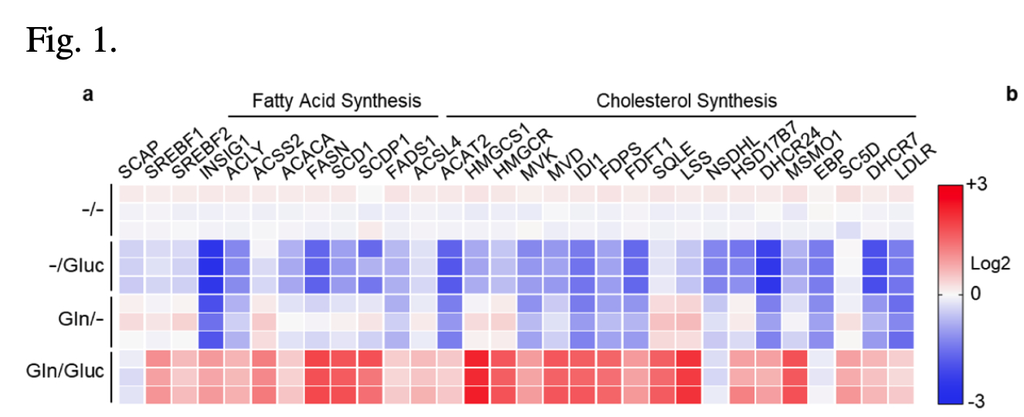

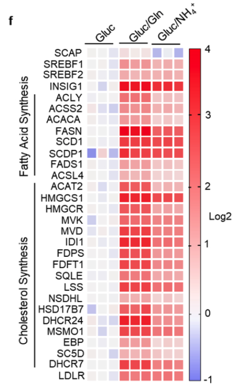

**Can you find evidence, i.e. publications, to support some of the results that you see. How does this evidence support your results.** I also found a [paper](https://febs.onlinelibrary.wiley.com/doi/full/10.1111/j.1742-4658.2011.08204.x)(Inoue et al. 2011) that supports the result that I see from the differential expression analysis and ORA. This paper indicates that genes related to lipid homeostasis is highly related to the amount of glutamine consumed by the cells. In my analysis, I obtained that genes that are known to be important in the process of fatty acid and cholesterol synthesis are up-regulated (higher expression) when treated by the glutamine and glucose, which matches with the point published by the [paper](https://febs.onlinelibrary.wiley.com/doi/full/10.1111/j.1742-4658.2011.08204.x)(Inoue et al. 2011) I mentioned.

# References

Cheng, Geng, Li, Zhong, Wang, and Mo Cheng Zhao. 2022. “Ammonia Stimulates SCAP/Insig Dissociation and SREBP-1 Activation to Promote Lipogenesis and Tumor Growth.” *Nature Metabolism* 4: 575--588.

Gu, Zuguang. 2022. “Complex Heatmap Visualization.” *iMeta*. https://doi.org/10.1002/imt2.43.

Gu, Zuguang, Lei Gu, Roland Eils, Matthias Schlesner, and Benedikt Brors. 2014. “Circlize Implements and Enhances Circular Visualization in r.” *Bioinformatics* 30: 2811–12.

Inoue, J., Y. Ito, Shimada S., S. Satoh, T. Sasaki, and Kamoshida Hashidume T. 2011. “Glutamine Stimulates the Gene Expression and Processing of Sterol Regulatory Element Binding Proteins, Thereby Increasing the Expression of Their Target Genes.” *The FEBS Journal* 278: 2739–50.

Kolberg, Liis, Uku Raudvere, Ivan Kuzmin, Jaak Vilo, and Hedi Peterson. 2020. “Gprofiler2– an r Package for Gene List Functional Enrichment Analysis and Namespace Conversion Toolset g:profiler.” *F1000Research* 9 (ELIXIR) (709).

Morgan, Martin, and Marcel Ramos. 2023. *BiocManager: Access the Bioconductor Project Package Repository*. https://CRAN.R-project.org/package=BiocManager.

Robinson, Mark D, Davis J McCarthy, and Gordon K Smyth. 2010. “edgeR: A Bioconductor Package for Differential Expression Analysis of Digital Gene Expression Data.” *Bioinformatics* 26 (1): 139–40. https://doi.org/10.1093/bioinformatics/btp616.

Slowikowski, Kamil. 2024. *Ggrepel: Automatically Position Non-Overlapping Text Labels with ’Ggplot2’*. https://CRAN.R-project.org/package=ggrepel.

Wickham, Hadley. 2016. *Ggplot2: Elegant Graphics for Data Analysis*. Springer-Verlag New York. https://ggplot2.tidyverse.org.

Wickham, Hadley, Romain François, Lionel Henry, Kirill Müller, and Davis Vaughan. 2023. *Dplyr: A Grammar of Data Manipulation*. https://CRAN.R-project.org/package=dplyr.

Xie, Yihui. 2023. *Knitr: A General-Purpose Package for Dynamic Report Generation in r*. https://yihui.org/knitr/.